# Homework 1

Donovan Kott

2023-09-20

Import and View Data set

```r
library(readxl)
Data1<- read_excel("C:/Users/dmkot/OneDrive/Documents/Grad/Fall 2023/Business Forecasting/Typical_Employee_Survey_Data.xlsx", col_names = FALSE)
View(Data1)
```

Give each column a name to provide context

```r
names(Data1)[1] <- "Age"
names(Data1)[2] <- "Gender"
names(Data1)[3] <- "Job Satisfaction"
names(Data1)[4] <- "Job Characteristics"
names(Data1)[5] <- "Service Time"
names(Data1)[6] <- "Promotion Likeliness"
names(Data1)[7] <- "Decision Ability"
names(Data1)[8] <- "Budget Responsibility"
names(Data1)[9] <- "Proudness"
names(Data1)[10] <- "Stay if Less Money?"
names(Data1)[11] <- "Coworker Relationships"
View(Data1)
```

See Column names

```r
head(Data1)
```

```
## # A tibble: 6 × 11
##     Age Gender `Job Satisfaction` `Job Characteristics` `Service Time`
##   <dbl>  <dbl>              <dbl>                 <dbl>          <dbl>
## 1    35      1                  2                     4            3
## 2    33      1                  2                     3            9
## 3    23      1                  1                     1            1.5
## 4    60      1                  1                     1           20
## 5    35      1                  2                     1            3
## 6    34      2                  2                     1            6
## # ℹ 6 more variables: `Promotion Likeliness` <dbl>, `Decision Ability` <dbl>,
## #   `Budget Responsibility` <dbl>, Proudness <dbl>,
## #   `Stay if Less Money?` <dbl>, `Coworker Relationships` <dbl>
```

See what kind of data type each column is. Currently they are all numerical but that is not the case. We need to convert the survey type ones into factors

```r
str(Data1)
```

```
## tibble [122 × 11] (S3: tbl_df/tbl/data.frame)
##  $ Age                   : num [1:122] 35 33 23 60 35 34 61 59 37 30 ...
##  $ Gender                : num [1:122] 1 1 1 1 1 2 2 1 2 1 ...
##  $ Job Satisfaction      : num [1:122] 2 2 1 1 2 2 1 2 1 1 ...
##  $ Job Characteristics   : num [1:122] 4 3 1 1 1 1 1 5 5 5 ...
##  $ Service Time          : num [1:122] 3 9 1.5 20 3 6 0.75 1.5 3 5 ...
##  $ Promotion Likeliness  : num [1:122] 1 5 1 3 3 1 5 2 4 2 ...
##  $ Decision Ability      : num [1:122] 2 2 2 2 2 2 3 1 3 2 ...
##  $ Budget Responsibility : num [1:122] 1 1 2 2 1 2 2 2 1 1 ...
##  $ Proudness             : num [1:122] 2 2 1 1 2 2 2 2 2 1 ...
##  $ Stay if Less Money?   : num [1:122] 5 2 5 1 4 4 4 4 2 2 ...
##  $ Coworker Relationships: num [1:122] 2 1 2 1 2 4 1 1 3 2 ...
```

Converting to Factors and renaming levels to give better context. Gender: The graphs shows more males than females

```r
Data1$Gender <- as.factor(Data1$Gender)
levels(Data1$Gender) = c("M", "F")
levels(Data1$Gender)
```

```
## [1] "M" "F"
```

```r
table(Data1$Gender)
```

```
##
##  M  F
## 70 52
```

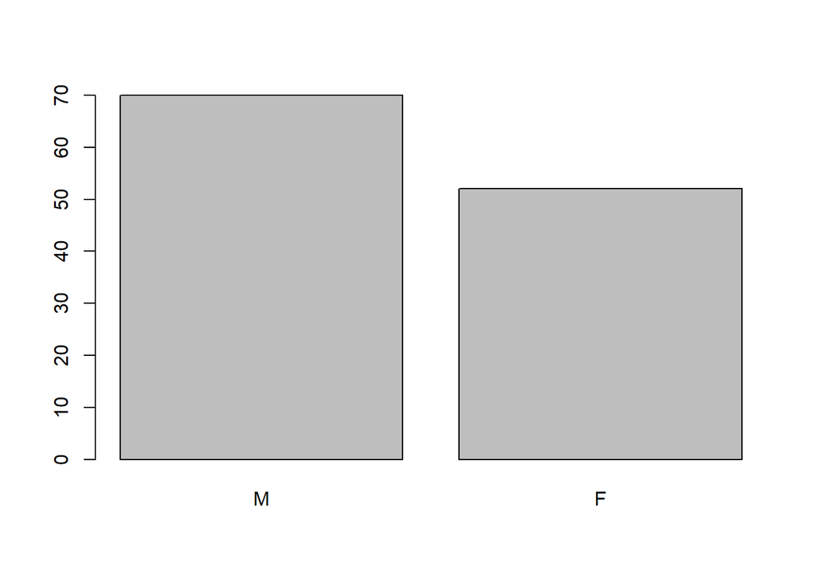

```r
plot(Data1$Gender)
```

Job Satisfaction: The graph shows majority are Very or Moderately Satisfied

```r
Data1$`Job Satisfaction` <- as.factor(Data1$`Job Satisfaction`)
levels(Data1$`Job Satisfaction`) = c("Very Satisfied", "Moderately Satisfied" , "A Little Dissatisfied", "Very Dissatisfied")
levels(Data1$`Job Satisfaction`)
```

```
## [1] "Very Satisfied"        "Moderately Satisfied"  "A Little Dissatisfied"
## [4] "Very Dissatisfied"
```

```r
table(Data1$`Job Satisfaction`)
```

```
##
##        Very Satisfied  Moderately Satisfied A Little Dissatisfied
##                    65                    44                     6
##     Very Dissatisfied
##                     7
```

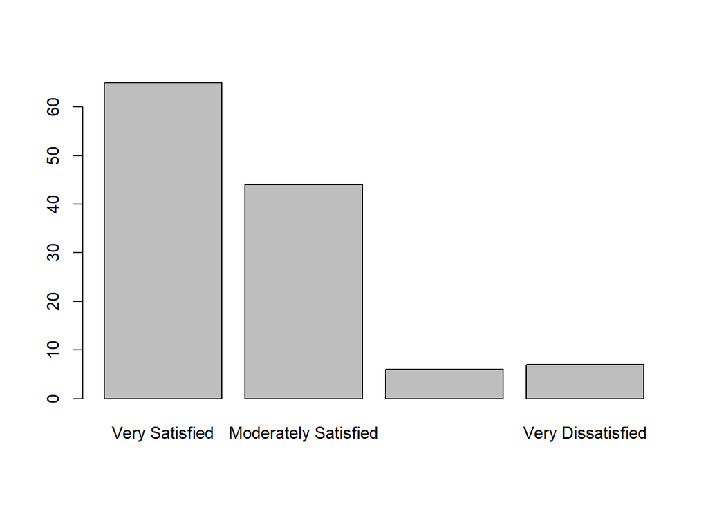

```r
plot(Data1$`Job Satisfaction`)
```

Job Characteristics: A large portion are Enjoying the work

```r
Data1$`Job Characteristics` <- as.factor(Data1$`Job Characteristics`)
levels(Data1$`Job Characteristics`) = c("High Income", "No Danger of Being Fired" , "Flexible Hours", "Opportunities for Advancement", "Enjoying the Work")
levels(Data1$`Job Characteristics`)
```

```
## [1] "High Income"                   "No Danger of Being Fired"
## [3] "Flexible Hours"                "Opportunities for Advancement"
## [5] "Enjoying the Work"
```

```r
table(Data1$`Job Characteristics`)
```

```
##
##                   High Income      No Danger of Being Fired
##                            26                             8
##                Flexible Hours Opportunities for Advancement
##                             6                            18
##             Enjoying the Work
##                            64
```

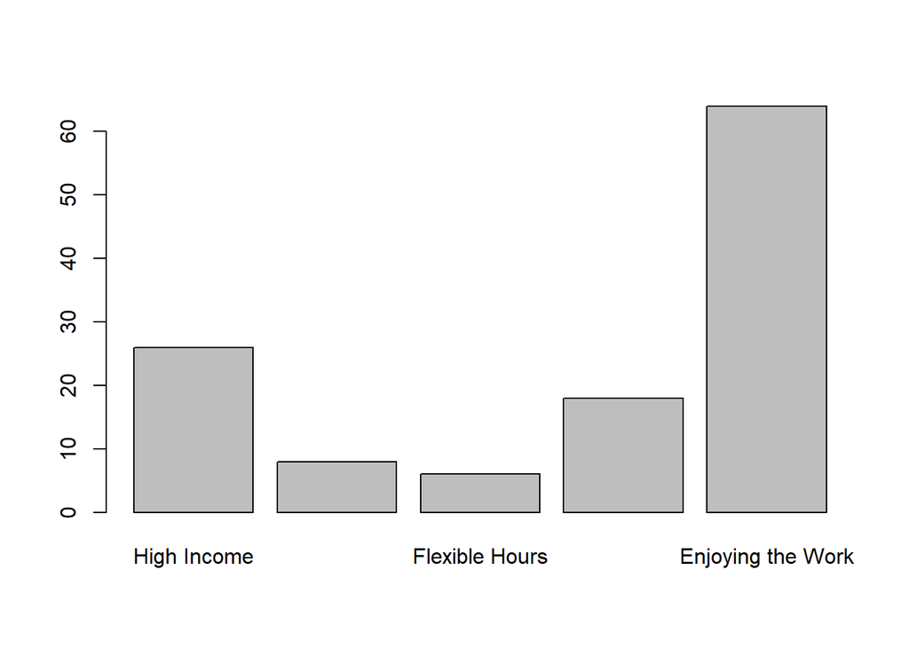

```r
plot(Data1$`Job Characteristics`)
```

Promotion Likeliness: A majority is Unlikely or Very Unlikely

```r
Data1$`Promotion Likeliness` <- as.factor(Data1$`Promotion Likeliness`)
levels(Data1$`Promotion Likeliness`) = c("Very Likely", "Likely" , "Not Sure", "Unlikely", "Very Unlikely")
levels(Data1$`Promotion Likeliness`)
```

```
## [1] "Very Likely"   "Likely"        "Not Sure"      "Unlikely"
## [5] "Very Unlikely"
```

```r
table(Data1$`Promotion Likeliness`)
```

```
##
##   Very Likely        Likely      Not Sure      Unlikely Very Unlikely
##            21            28             6            29            38
```

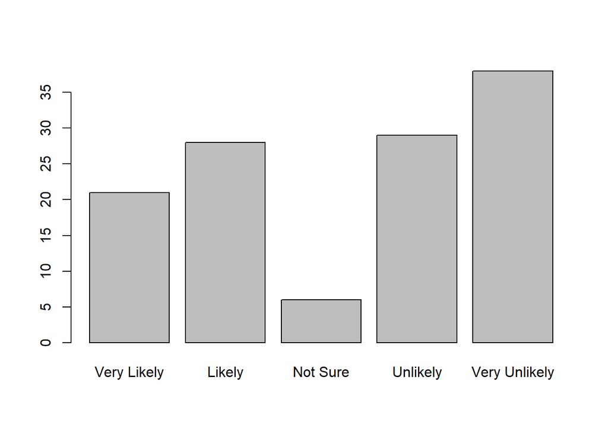

```r
plot(Data1$`Promotion Likeliness`)
```

Decision Ability: There seems to be a pretty even split between making decisions and not

```r
Data1$`Decision Ability` <- as.factor(Data1$`Decision Ability`)
levels(Data1$`Decision Ability`) = c("Always", "Much of the Time" , "Sometimes", "Never")
levels(Data1$`Decision Ability`)
```

```
## [1] "Always"           "Much of the Time" "Sometimes"        "Never"
```

```r
table(Data1$`Decision Ability`)
```

```
##
##           Always Much of the Time        Sometimes            Never
##               17               57               45                3
```

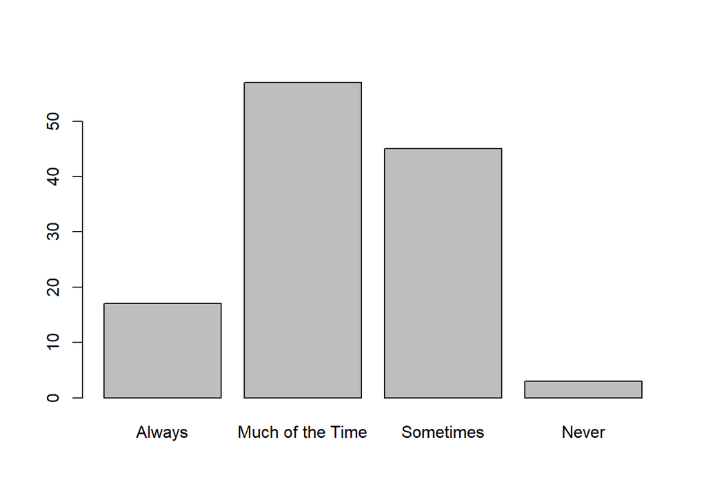

```r
plot(Data1$`Decision Ability`)
```

Budget Responsibility: A majority have budget responsibility

```r
Data1$`Budget Responsibility` <- as.factor(Data1$`Budget Responsibility`)
levels(Data1$`Budget Responsibility`) = c("Yes", "No")
levels(Data1$`Budget Responsibility`)
```

```
## [1] "Yes" "No"
```

```r
table(Data1$`Budget Responsibility`)
```

```
##
## Yes  No
##  67  55
```

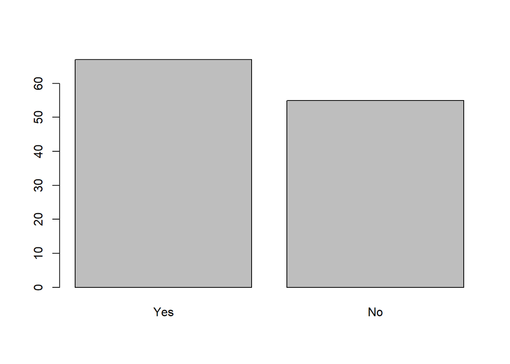

```r
plot(Data1$`Budget Responsibility`)
```

Proudness: A large portion is very proud or somewhat proud

```r
Data1$Proudness <- as.factor(Data1$Proudness)
levels(Data1$Proudness) = c("Very Proud", "Somewhat Proud", "Indifferent" , "Not at All Proud")
levels(Data1$Proudness)
```

```
## [1] "Very Proud"       "Somewhat Proud"   "Indifferent"      "Not at All Proud"
```

```r
table(Data1$Proudness)
```

```
##
##       Very Proud   Somewhat Proud      Indifferent Not at All Proud
##               37               75                9                1
```

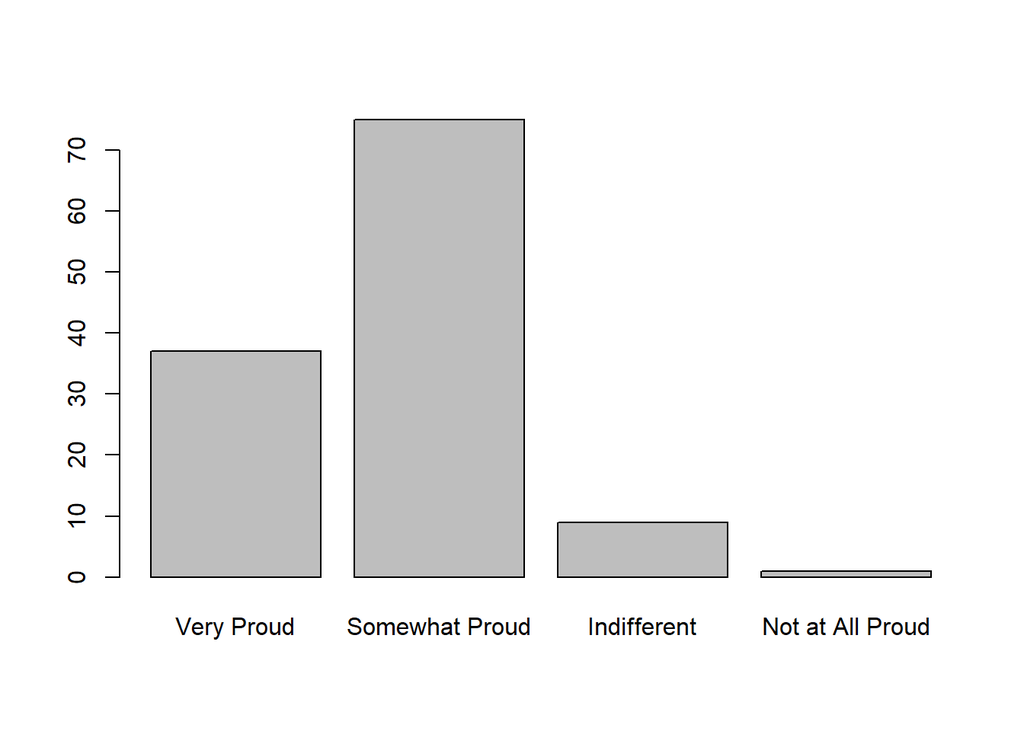

```r
plot(Data1$Proudness)
```

Stay if Less Money?: A majority is unlikely or very unlikely to stay if offered more money somewhere else

```r
Data1$`Stay if Less Money?` <- as.factor(Data1$`Stay if Less Money?`)
levels(Data1$`Stay if Less Money?`) = c("Very Likely", "Likely" , "Not Sure", "Unlikely", "Very Unlikely")
levels(Data1$`Stay if Less Money?`)
```

```
## [1] "Very Likely"   "Likely"        "Not Sure"      "Unlikely"
## [5] "Very Unlikely"
```

```r
table(Data1$`Stay if Less Money?`)
```

```
##
##   Very Likely        Likely      Not Sure      Unlikely Very Unlikely
##            16            30             1            57            18
```

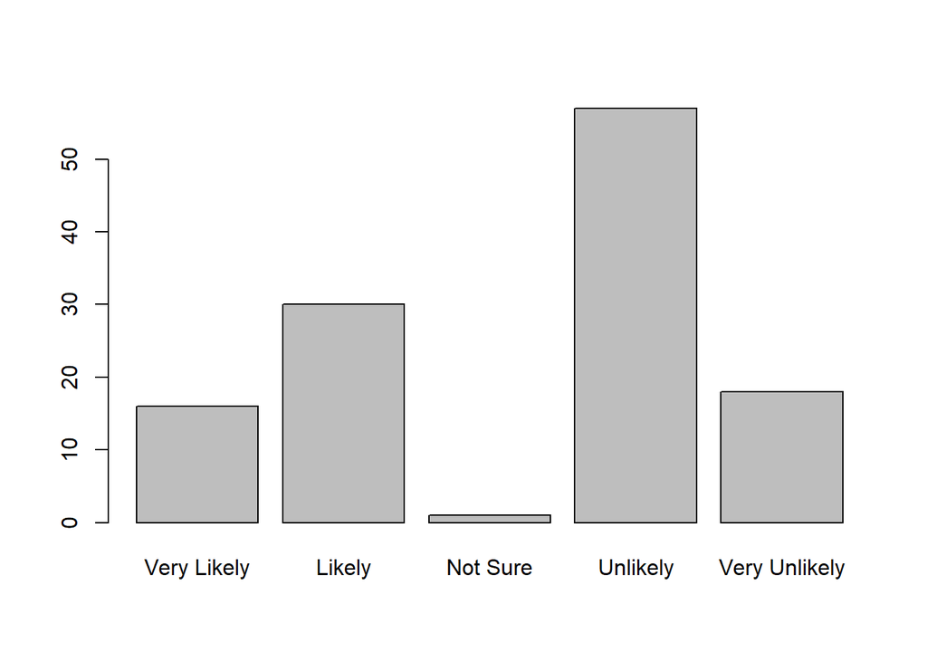

```r
plot(Data1$`Stay if Less Money?`)
```

Coworker Relationships: A large portion have very good or good relationships with coworkers

```r
Data1$`Coworker Relationships` <- as.factor(Data1$`Coworker Relationships`)
levels(Data1$`Coworker Relationships`) = c("Very Good", "Good" , "So So", "Bad", "Very Bad")
levels(Data1$`Coworker Relationships`)
```

```
## [1] "Very Good" "Good"      "So So"     "Bad"       "Very Bad"
```

```r
table(Data1$`Coworker Relationships`)
```

```
##
## Very Good      Good     So So       Bad  Very Bad
##        51        49        19         3         0
```